# Analyze and Model Crime Data

# Overview

In this homework assignment, you will explore, analyze and model a data set containing information on crime for various neighborhoods of a major city. Each record has a response variable indicating whether or not the crime rate is above the median crime rate (1) or not(0).  
Your objective is to build a binary logistic regression model on the training data set to predict whether the neighborhood will be at risk for high crime levels. You will provide classifications and probabilities for the evaluation data set using your binary logistic regression model. You can only use the variables given to you (or variables that you derive from the variables provided). Below is a short description of the variables of interest in the data set:

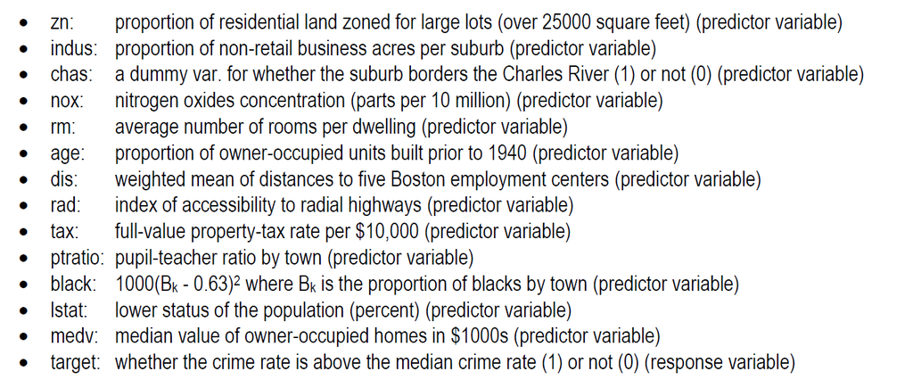

```r
library(tinytex)
```

# 1 - Data Exploration

In this section, we are going to explore the data to see the data type and data structure, We will also check the correlation among the variables and most importantly to see if there are missing values in the data but first let’s read both training and test datasets.

| zn | indus | chas | nox | rm | age | dis | rad | tax | ptratio | lstat | medv | target |
| --- | --- | --- | --- | --- | --- | --- | --- | --- | --- | --- | --- | --- |
| 0 | 19.58 | 0 | 0.605 | 7.929 | 96.2 | 2.0459 | 5 | 403 | 14.7 | 3.70 | 50.0 | 1 |
| 0 | 19.58 | 1 | 0.871 | 5.403 | 100.0 | 1.3216 | 5 | 403 | 14.7 | 26.82 | 13.4 | 1 |
| 0 | 18.10 | 0 | 0.740 | 6.485 | 100.0 | 1.9784 | 24 | 666 | 20.2 | 18.85 | 15.4 | 1 |
| 30 | 4.93 | 0 | 0.428 | 6.393 | 7.8 | 7.0355 | 6 | 300 | 16.6 | 5.19 | 23.7 | 0 |
| 0 | 2.46 | 0 | 0.488 | 7.155 | 92.2 | 2.7006 | 3 | 193 | 17.8 | 4.82 | 37.9 | 0 |
| 0 | 8.56 | 0 | 0.520 | 6.781 | 71.3 | 2.8561 | 5 | 384 | 20.9 | 7.67 | 26.5 | 0 |

Both training and evaluation datasets have been read using read.csv function and above table is a sample of training dataset. Before jumping in model building, we have to explore what kind of dataset we have, is it usable at this moment or we have to do data preparation which is the case usually. According to variable’s documentation, target and chas seem to be factor variables that’s why we converted them into factors to be able to explore the data in a right way. Now let’s explore the data structure using skim function from skimr package. This is an efficient function which not only produces the statistics summary but also builds histogram for each numberic variable, show number of missing values and quantiles. This gives a bird eye view of the training dataset. We double checked the total number of missing values with colSums and missmap functions as well to verify if we have any missing value and seems like we do not have missing values.

```
## [1] "Chinese (Simplified)_China.936"
```

| skim_type | skim_variable | n_missing | complete_rate | factor.ordered | factor.n_unique | factor.top_counts | numeric.mean | numeric.sd | numeric.p0 | numeric.p25 | numeric.p50 | numeric.p75 | numeric.p100 | numeric.hist |
| --- | --- | --- | --- | --- | --- | --- | --- | --- | --- | --- | --- | --- | --- | --- |
| factor | chas | 0 | 1 | FALSE | 2 | 0: 433, 1: 33 | NA | NA | NA | NA | NA | NA | NA | NA |
| factor | target | 0 | 1 | FALSE | 2 | 0: 237, 1: 229 | NA | NA | NA | NA | NA | NA | NA | NA |
| numeric | zn | 0 | 1 | NA | NA | NA | 11.5772532 | 23.3646511 | 0.0000 | 0.000000 | 0.00000 | 16.25000 | 100.0000 | ▇▁▁▁▁ |
| numeric | indus | 0 | 1 | NA | NA | NA | 11.1050215 | 6.8458549 | 0.4600 | 5.145000 | 9.69000 | 18.10000 | 27.7400 | ▇▆▁▇▁ |
| numeric | nox | 0 | 1 | NA | NA | NA | 0.5543105 | 0.1166667 | 0.3890 | 0.448000 | 0.53800 | 0.62400 | 0.8710 | ▇▇▅▃▁ |
| numeric | rm | 0 | 1 | NA | NA | NA | 6.2906738 | 0.7048513 | 3.8630 | 5.887250 | 6.21000 | 6.62975 | 8.7800 | ▁▂▇▂▁ |
| numeric | age | 0 | 1 | NA | NA | NA | 68.3675966 | 28.3213784 | 2.9000 | 43.875000 | 77.15000 | 94.10000 | 100.0000 | ▂▂▂▃▇ |
| numeric | dis | 0 | 1 | NA | NA | NA | 3.7956929 | 2.1069496 | 1.1296 | 2.101425 | 3.19095 | 5.21460 | 12.1265 | ▇▅▂▁▁ |
| numeric | rad | 0 | 1 | NA | NA | NA | 9.5300429 | 8.6859272 | 1.0000 | 4.000000 | 5.00000 | 24.00000 | 24.0000 | ▇▂▁▁▃ |
| numeric | tax | 0 | 1 | NA | NA | NA | 409.5021459 | 167.9000887 | 187.0000 | 281.000000 | 334.50000 | 666.00000 | 711.0000 | ▇▇▅▁▇ |
| numeric | ptratio | 0 | 1 | NA | NA | NA | 18.3984979 | 2.1968447 | 12.6000 | 16.900000 | 18.90000 | 20.20000 | 22.0000 | ▁▃▅▅▇ |
| numeric | lstat | 0 | 1 | NA | NA | NA | 12.6314592 | 7.1018907 | 1.7300 | 7.042500 | 11.35000 | 16.93000 | 37.9700 | ▇▇▅▂▁ |
| numeric | medv | 0 | 1 | NA | NA | NA | 22.5892704 | 9.2396814 | 5.0000 | 17.025000 | 21.20000 | 25.00000 | 50.0000 | ▂▇▅▁▁ |

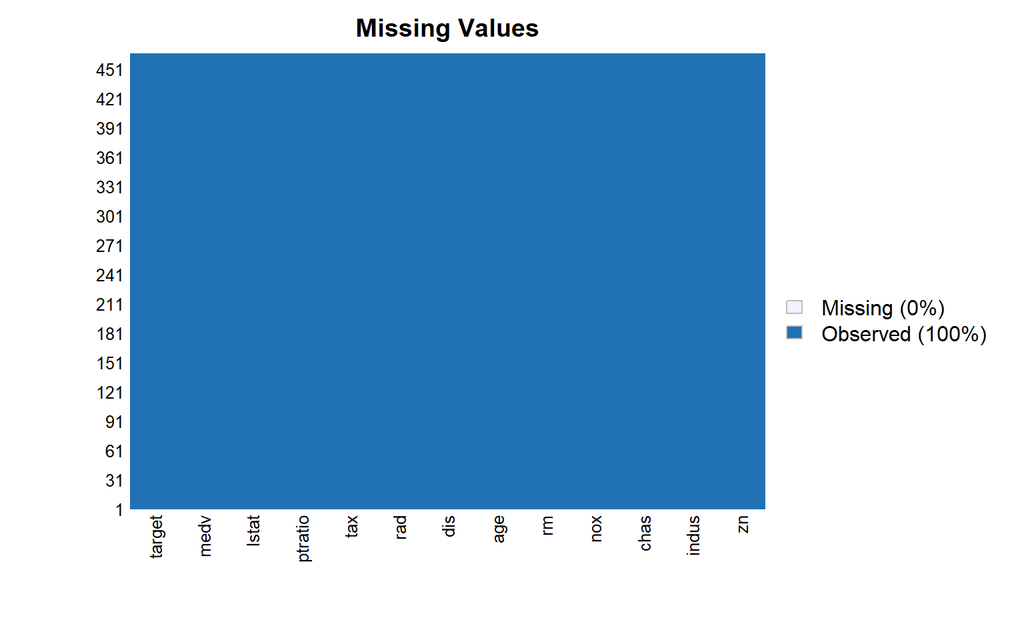

```
##      zn   indus    chas     nox      rm     age     dis     rad     tax ptratio
##       0       0       0       0       0       0       0       0       0       0
##   lstat    medv  target
##       0       0       0
```

It’s important to check the correlation of predictors among themselves and especially with the target variable. Now we are going to create boxplot and correlations to explore more.

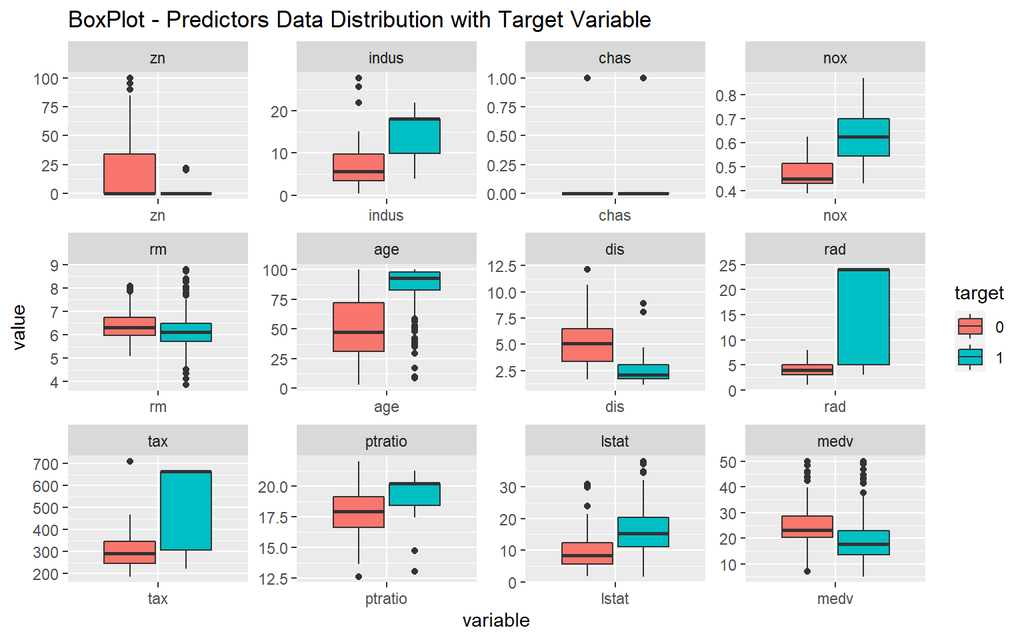

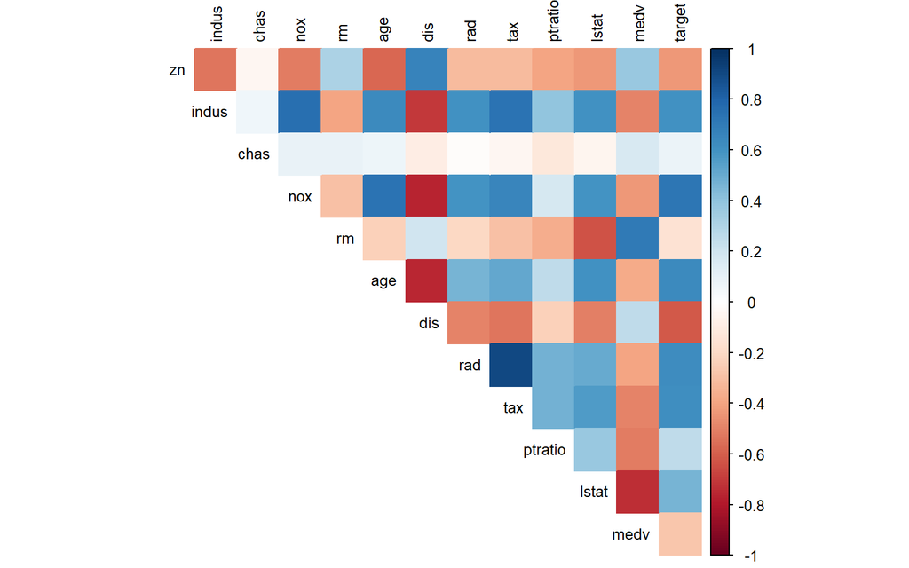

| rowname | Variable | Correlation |
| --- | --- | --- |
| target | target | 1.0000000 |
| nox | target | 0.7261062 |
| age | target | 0.6301062 |
| rad | target | 0.6281049 |
| tax | target | 0.6111133 |
| indus | target | 0.6048507 |
| lstat | target | 0.4691270 |
| ptratio | target | 0.2508489 |
| chas | target | 0.0800419 |
| rm | target | -0.1525533 |
| medv | target | -0.2705507 |
| zn | target | -0.4316818 |
| dis | target | -0.6186731 |

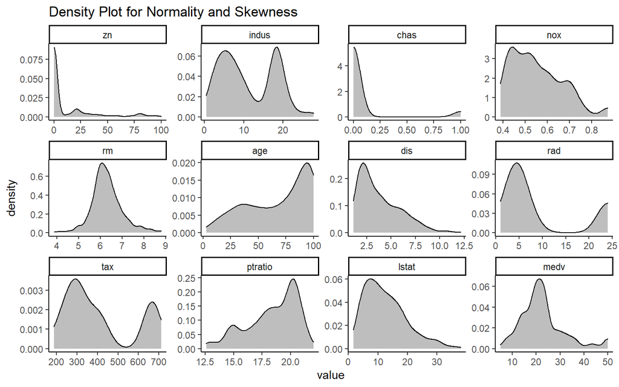

```
##          zn       indus        chas         nox          rm         age
##  2.17681518  0.28854503  3.33548988  0.74632807  0.47932023 -0.57770755
##         dis         rad         tax     ptratio       lstat        medv
##  0.99889262  1.01027875  0.65931363 -0.75426808  0.90558642  1.07669198
##      target
##  0.03422935
```

According to correlation plot and matrix, nox, age, rad, tax and indus are positively correlated with target. lstat, ptratio and chas have weak correlations with target variable. dis have good negative correlation followed by zn medv and rm which do not seem to have strong correlation with target varible. It is also important to discuss that the predictors are mostly not normally distributed with skewed on both sides other than rm. We might have to go through data preparation step to make the data usable for model building. In last, we are going to split the training set into two subsets i.e. train and test which will be helpful for accuracy checking before predicting the target variable in evaluation dataset.

# 2 - Data Preparation

There are few issues in the data. Although there are no missing values but most of the variables seem to be skewed and not normally distributed. Outliers have also seen in some variables which need to be checked either the values make sense or not. If not then some of the high outliers will be replaced with either median or knn function. We will also use log transformation before going ahead and we will explore if log transformation is enough.

## Data Splitting

Let’s start with splitting the training dataset into train and test datasets which will help us to check the accuracy of our model in the next step. Keep in mind that evaluation data does not have target variable because we will be predicting the values but how are we going to make sure the predicted values are accurate? The answer is data splitting i.e. training data. We will be using createDataPartition function from caret library to split the datasets with 70 percent train and 30 percent test data. It’s important to check out the skewness as well as previously in boxplot we saw that there are some outliers but are they problematic?

```
##          zn       indus        chas         nox          rm         age
##  2.17681518  0.28854503  3.33548988  0.74632807  0.47932023 -0.57770755
##         dis         rad         tax     ptratio       lstat        medv
##  0.99889262  1.01027875  0.65931363 -0.75426808  0.90558642  1.07669198
##      target
##  0.03422935
```

Skewness function from e1071 was used with sapply function to create the skewness of all the variables. If the values are positive then those variables are positively skewed and vice versa. If skewness is 0 then the data is perfectly symmetric but it’s very unlikely in the real world scenario. Statisticians suggest anything under +1 and -1 to be in a safe zone. Another statistican has also considered anything under +2 and -2 are fine too. According to the above results, zn and chas are not symmetric and hence we have to use log transformation to make them symmetric but in this case we won’t consider transforming chas because it is a categorical data. It will leave us using log transformation only on zn. Let’s do this:

## log transformation

```
##         zn      indus       chas        nox         rm        age        dis
##  1.1954317  0.3708873  3.2567321  0.8108244  0.4843153 -0.5322325  0.9721716
##        rad        tax    ptratio      lstat       medv     target
##  1.1317640  0.7385414 -0.8218609  0.9700911  0.9700927  0.1036391
```

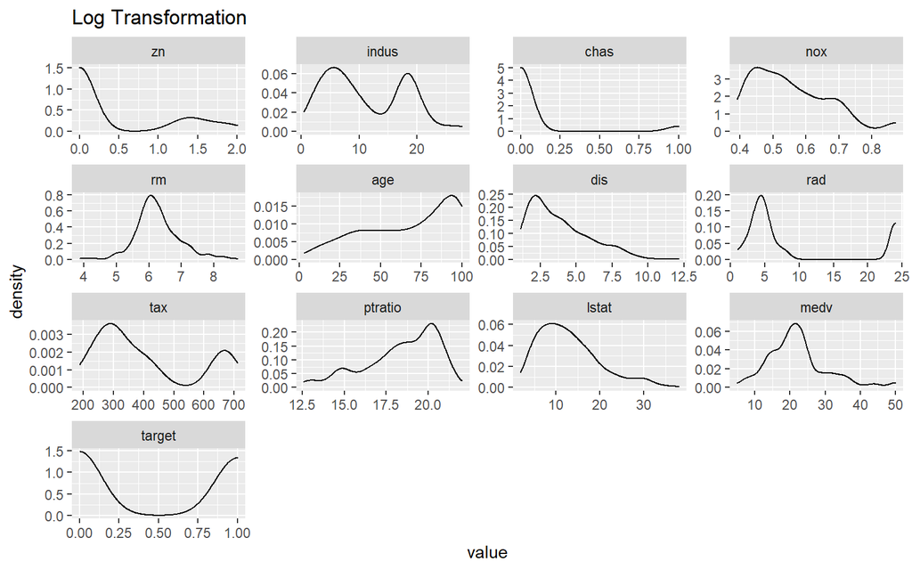

Now it’s very close to 1 which is still not ideal but will consider it safer than before for model building. We were planning to remove the extreme outliers but seems like we had only problem with zn which is resolved after transformation that’s why we will continue working ahead. Plot has also slightly improved as compared with before.

## BoxCox Transformation

Although log transformation has already made the data symmetrical but we will also boxcox transformation to see if using model based on boxcox transformation will give better results in terms of accuracy as compared with log transformed data or not. We will apply boxcox transformation both on train and test datasets.

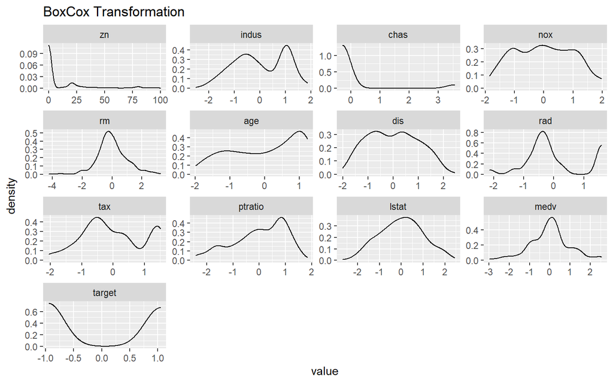

```
##           zn        indus         chas          nox           rm          age
##  2.353729370 -0.120195838  3.256732134  0.068418489  0.026658478 -0.366340589
##          dis          rad          tax      ptratio        lstat         medv
##  0.106811243  0.402503618  0.069764777 -0.613098264 -0.002592159 -0.039697233
##       target
##  0.103639097
```

Although the skewness did not improve much for zn but overall it seems to be symmetrical as compared with the results of log transformation. At this point we are not sure which transformation will give better predictions until later. We will keep both transformed datasets and will check them both as seperate models.  
The data is ready to be used for model building. We are going to use backward elimination model and another model that will be result of cumulative variables that have collinearity. We will discuss about it in detail in the next step.

# 3 - Build Models

## Model 1 - Backward elimination on Log Transformed data

In this model, we are going to use log transformed data and remove the least insignificant variables one-by-one until the model becomes completely significant. Let’s dive in and see how this model is doing. We had checked the skewness for the variables and only zn seemed to be skewed for which we adjusted it to log + 1 which not only handled transformation but also handles missing value if exists. After creating a model, we had to remove chas, lstat, rm, indus, ptratio, tax and dis one by one to keep only the significant variables in the model and seems like only age, nox, rad and medv have significant impact on target with adjusted r-square of 0.59. R-square was not initially 0.59 which did not improve at all after eliminating the insignificant variables one by one and it makes sense as they have least to no impact on target variable. There were some collinearity between tax and rad but since tax has been excluded from the model that’s why there is no more any multicollinearity among the variables as the values of VIF are less than 10. Important point is here that only zn was adjusted to log but since it was removed that’s we can say model is normal and not transformed.

| Observations | 327 |
| --- | --- |
| Dependent variable | target |
| Type | OLS linear regression |

| F(4,322) | 118.76 |
| --- | --- |
| R2 | 0.60 |
| Adj. R2 | 0.59 |

|  | Est. | S.E. | t val. | p |
| --- | --- | --- | --- | --- |
| (Intercept) | -1.12 | 0.13 | -8.62 | 0.00 |
| nox | 1.81 | 0.24 | 7.50 | 0.00 |
| age | 0.00 | 0.00 | 3.90 | 0.00 |
| rad | 0.02 | 0.00 | 7.57 | 0.00 |
| medv | 0.01 | 0.00 | 2.90 | 0.00 |

Standard errors: OLS

Multicollinearity

| Parameter | VIF | SE_factor |
| --- | --- | --- |
| nox | 2.760468 | 1.661466 |
| age | 2.344391 | 1.531141 |
| rad | 1.623970 | 1.274351 |
| medv | 1.433166 | 1.197149 |

## Model 2 - Backward elimination on BoxCox Transformed data

| Observations | 327 |
| --- | --- |
| Dependent variable | target |
| Type | OLS linear regression |

| F(5,321) | 104.74 |
| --- | --- |
| R2 | 0.62 |
| Adj. R2 | 0.61 |

|  | Est. | S.E. | t val. | p |
| --- | --- | --- | --- | --- |
| (Intercept) | -0.00 | 0.03 | -0.00 | 1.00 |
| nox | 0.65 | 0.09 | 7.61 | 0.00 |
| age | 0.20 | 0.06 | 3.37 | 0.00 |
| dis | 0.23 | 0.08 | 2.93 | 0.00 |
| rad | 0.33 | 0.04 | 7.55 | 0.00 |
| medv | 0.12 | 0.04 | 2.75 | 0.01 |

Standard errors: OLS

Multicollinearity

| Parameter | VIF | SE_factor |
| --- | --- | --- |
| nox | 6.140573 | 2.478018 |
| age | 3.082054 | 1.755578 |
| dis | 5.293362 | 2.300731 |
| rad | 1.592763 | 1.262047 |
| medv | 1.508302 | 1.228129 |

## Model 3 - Using Stepwise Regression

Although we have used backward elimination in which we eliminated insignificant variables one by one from the model as discussed before. We can use step() function which is more robust and it is used for stepwise regression. Basically, it eliminates all the insignificant variables one-by-one under the hood and brings the significant variables. This model is used only to verify the result of Model2 using step-wise regression.

```
## Start:  AIC=-305.39
## target ~ nox + age + dis + rad + medv
##
##        Df Sum of Sq    RSS     AIC
## <none>              123.88 -305.39
## - medv  1    2.9275 126.81 -299.75
## - dis   1    3.3095 127.19 -298.77
## - age   1    4.3841 128.27 -296.02
## - rad   1   22.0257 145.91 -253.88
## - nox   1   22.3745 146.26 -253.10
```

| Observations | 327 |
| --- | --- |
| Dependent variable | target |
| Type | OLS linear regression |

| F(5,321) | 104.74 |
| --- | --- |
| R2 | 0.62 |
| Adj. R2 | 0.61 |

|  | Est. | S.E. | t val. | p |
| --- | --- | --- | --- | --- |
| (Intercept) | -0.00 | 0.03 | -0.00 | 1.00 |
| nox | 0.65 | 0.09 | 7.61 | 0.00 |
| age | 0.20 | 0.06 | 3.37 | 0.00 |
| dis | 0.23 | 0.08 | 2.93 | 0.00 |
| rad | 0.33 | 0.04 | 7.55 | 0.00 |
| medv | 0.12 | 0.04 | 2.75 | 0.01 |

Standard errors: OLS

## Model 4 - Using glmulti

```
##
## Call:
## fitfunc(formula = as.formula(x), family = ..1, data = data)
##
## Deviance Residuals:
##     Min       1Q   Median       3Q      Max
## -1.7621  -0.2870  -0.0080   0.0057   3.2397
##
## Coefficients:
##               Estimate Std. Error z value Pr(>|z|)
## (Intercept) -36.411735   6.701072  -5.434 5.52e-08 ***
## zn           -0.052983   0.034824  -1.521  0.12815
## indus        -0.069985   0.048870  -1.432  0.15213
## nox          44.712077   8.392153   5.328 9.94e-08 ***
## age           0.032535   0.012388   2.626  0.00863 **
## dis           0.749006   0.262842   2.850  0.00438 **
## rad           0.569547   0.159955   3.561  0.00037 ***
## tax          -0.005851   0.003072  -1.905  0.05683 .
## ptratio       0.268150   0.129009   2.079  0.03766 *
## medv          0.089608   0.039255   2.283  0.02245 *
## ---
## Signif. codes:  0 '***' 0.001 '**' 0.01 '*' 0.05 '.' 0.1 ' ' 1
##
## (Dispersion parameter for binomial family taken to be 1)
##
##     Null deviance: 452.43  on 326  degrees of freedom
## Residual deviance: 152.03  on 317  degrees of freedom
## AIC: 172.03
##
## Number of Fisher Scoring iterations: 8
```

glmulti() function from glmulti package is one of the best automated function which optimizes the best performing model through simulating all possible models under the hood and finds the best performing model. It takes few time to optimize the model though. We will see which model performed best in terms of performance and accuracy in the next section.

# 4 - Select Models

## Model Performance

| Model | Type | AIC | BIC | R2 | R2_adjusted | RMSE | Sigma | BF | Performance_Score |
| --- | --- | --- | --- | --- | --- | --- | --- | --- | --- |
| model1 | lm | 189.4090 | 212.1487 | 0.5960003 | 0.5909817 | 0.3173751 | 0.3198297 | 1 | 0.6666667 |
| model2 | lm | 624.5961 | 651.1258 | 0.6199863 | 0.6140671 | 0.6155092 | 0.6212350 | 0 | 0.3333333 |
| model3 | lm | 624.5961 | 651.1258 | 0.6199863 | 0.6140671 | 0.6155092 | 0.6212350 | 0 | 0.3333333 |

| AIC | BIC | R2_Tjur | RMSE | Sigma | Log_loss | Score_log | Score_spherical | PCP |
| --- | --- | --- | --- | --- | --- | --- | --- | --- |
| 172.0349 | 209.9345 | 0.7092821 | 0.2638491 | 0.6925355 | 0.2324693 | -Inf | 0.024527 | 0.8550339 |

## Prediction Accuracy

```
## Confusion Matrix and Statistics
##
##           Reference
## Prediction  0  1
##          0 20  0
##          1 45 74
##
##                Accuracy : 0.6763
##                  95% CI : (0.5917, 0.7531)
##     No Information Rate : 0.5324
##     P-Value [Acc > NIR] : 0.0003971
##
##                   Kappa : 0.3212
##
##  Mcnemar's Test P-Value : 5.412e-11
##
##             Sensitivity : 0.3077
##             Specificity : 1.0000
##          Pos Pred Value : 1.0000
##          Neg Pred Value : 0.6218
##               Precision : 1.0000
##                  Recall : 0.3077
##                      F1 : 0.4706
##              Prevalence : 0.4676
##          Detection Rate : 0.1439
##    Detection Prevalence : 0.1439
##       Balanced Accuracy : 0.6538
##
##        'Positive' Class : 0
##
```

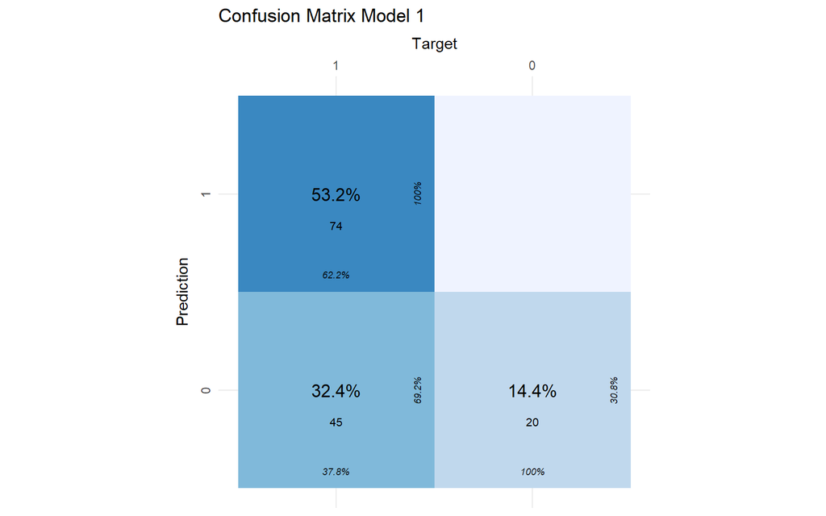

```
## Confusion Matrix and Statistics
##
##           Reference
## Prediction  0  1
##          0  0  0
##          1 65 74
##
##                Accuracy : 0.5324
##                  95% CI : (0.4459, 0.6174)
##     No Information Rate : 0.5324
##     P-Value [Acc > NIR] : 0.5346
##
##                   Kappa : 0
##
##  Mcnemar's Test P-Value : 2.051e-15
##
##             Sensitivity : 0.0000
##             Specificity : 1.0000
##          Pos Pred Value :    NaN
##          Neg Pred Value : 0.5324
##               Precision :     NA
##                  Recall : 0.0000
##                      F1 :     NA
##              Prevalence : 0.4676
##          Detection Rate : 0.0000
##    Detection Prevalence : 0.0000
##       Balanced Accuracy : 0.5000
##
##        'Positive' Class : 0
##
```

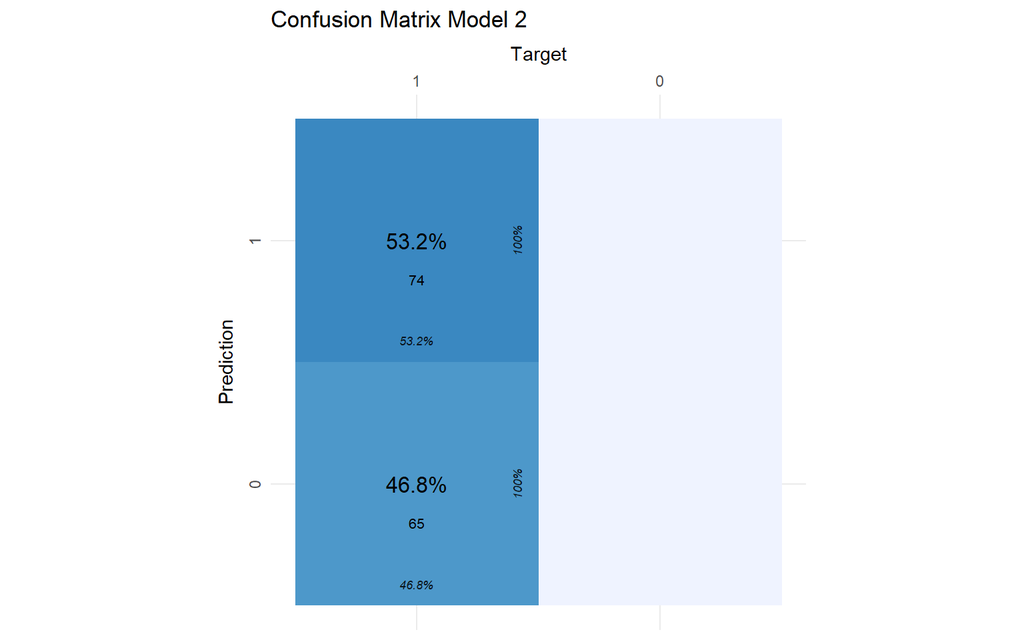

```
## Confusion Matrix and Statistics
##
##           Reference
## Prediction  0  1
##          0  0  0
##          1 65 74
##
##                Accuracy : 0.5324
##                  95% CI : (0.4459, 0.6174)
##     No Information Rate : 0.5324
##     P-Value [Acc > NIR] : 0.5346
##
##                   Kappa : 0
##
##  Mcnemar's Test P-Value : 2.051e-15
##
##             Sensitivity : 0.0000
##             Specificity : 1.0000
##          Pos Pred Value :    NaN
##          Neg Pred Value : 0.5324
##               Precision :     NA
##                  Recall : 0.0000
##                      F1 :     NA
##              Prevalence : 0.4676
##          Detection Rate : 0.0000
##    Detection Prevalence : 0.0000
##       Balanced Accuracy : 0.5000
##
##        'Positive' Class : 0
##
```

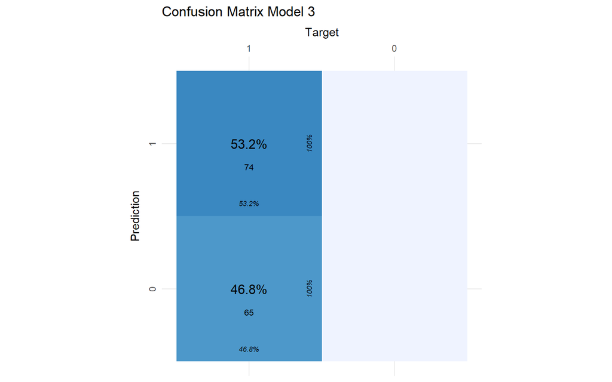

```
## Confusion Matrix and Statistics
##
##           Reference
## Prediction  0  1
##          0 60  5
##          1  5 69
##
##                Accuracy : 0.9281
##                  95% CI : (0.8717, 0.965)
##     No Information Rate : 0.5324
##     P-Value [Acc > NIR] : <2e-16
##
##                   Kappa : 0.8555
##
##  Mcnemar's Test P-Value : 1
##
##             Sensitivity : 0.9231
##             Specificity : 0.9324
##          Pos Pred Value : 0.9231
##          Neg Pred Value : 0.9324
##               Precision : 0.9231
##                  Recall : 0.9231
##                      F1 : 0.9231
##              Prevalence : 0.4676
##          Detection Rate : 0.4317
##    Detection Prevalence : 0.4676
##       Balanced Accuracy : 0.9278
##
##        'Positive' Class : 0
##
```

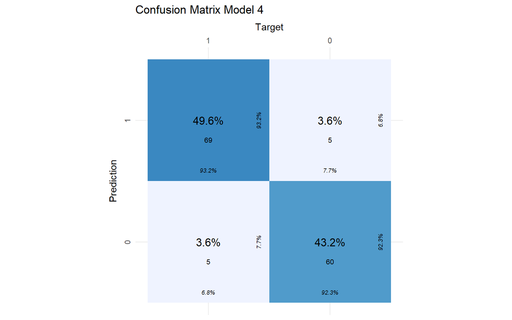

We will use model4 to predict the test set.

## Predicting the test set

```
##   zn indus chas   nox    rm  age    dis rad tax ptratio lstat medv target
## 1  0  7.07    0 0.469 7.185 61.1 4.9671   2 242    17.8  4.03 34.7      0
## 2  0  8.14    0 0.538 6.096 84.5 4.4619   4 307    21.0 10.26 18.2      1
## 3  0  8.14    0 0.538 6.495 94.4 4.4547   4 307    21.0 12.80 18.4      1
## 4  0  8.14    0 0.538 5.950 82.0 3.9900   4 307    21.0 27.71 13.2      0
## 5  0  5.96    0 0.499 5.850 41.5 3.9342   5 279    19.2  8.77 21.0      0
## 6 25  5.13    0 0.453 5.741 66.2 7.2254   8 284    19.7 13.15 18.7      0
```

# Appendix

```r
knitr::include_graphics('3.png')


# Reading multiple libraries together with pacman's p_load function
#Sys.setenv(JAVA_HOME= "C:\\Program Files\\Java\\jre1.8.0_261")
pacman::p_load(naniar, tidyverse, knitr, kableExtra, skimr, Amelia, reshape2, stats, corrplot,caret, e1071, jtools, performance, glmulti,cvms, ROCR)

training <- read.csv('C:/Users/hukha/Desktop/MS - Data Science/Data 621/HW3/crime-training-data_modified.csv')
training2 <- training # for melting and boxploting
evaluation <- read.csv('C:/Users/hukha/Desktop/MS - Data Science/Data 621/HW3/crime-evaluation-data_modified.csv')

training %>% head() %>% kable() %>% kableExtra::kable_styling()

# Converting into factor variables
var <- c("chas","target")
training[,var] <- lapply(training[,var], as.factor)
evaluation$chas <- as.factor(evaluation$chas)

Sys.setlocale("LC_CTYPE", "Chinese") # Don't remove this line otherwise histogram will not show up correctly
skim(training)  %>% kable() %>% kable_styling(full_width=FALSE) # Using skimr package
missmap(training, main="Missing Values") # using Amelia package
colSums(is.na(training))

# Boxplot to see distributions with target variable
melt(training2, id.vars='target') %>% mutate(target = as.factor(target)) %>%
  ggplot(., aes(x=variable, y=value))+geom_boxplot(aes(fill=target))+facet_wrap(~variable, dir='h',scales='free')+ labs(title="BoxPlot - Predictors Data Distribution with Target Variable")

# Correlation matrix among variables
training2 %>%
  cor(., use = "complete.obs") %>%
  corrplot(., method = "color", type = "upper", tl.col = "black", tl.cex=.8, diag = FALSE)

# Correlation table
correlation <- training2 %>%
  cor(., use = "complete.obs") %>%
  as.data.frame() %>%
  rownames_to_column()%>%
  gather(Variable, Correlation, -rowname)

correlation %>%
  filter(Variable == "target") %>%
     arrange(desc(Correlation)) %>%
  kable() %>%
  kable_styling(full_width = FALSE)

# Density plot to check normality
melt(training2, id.vars='target') %>% mutate(target = as.factor(target)) %>%
  ggplot(., aes(x=value))+geom_density(fill='gray')+facet_wrap(~variable, scales='free')+
  labs(title="Density Plot for Normality and Skewness") +
  theme_classic()

# Skewness and outliers
sapply(training2, skewness, function(x) skewness(x))

set.seed(1003)
training_partition <- createDataPartition(training2$target, p=0.7, list = FALSE, times=1)
train2 <- training2[training_partition, ]
test2 <- training2[-training_partition, ]

sapply(training2, skewness, function(x) skewness(x))

train_log <- train2 # copy of basic model for log transformation
test_log <- test2


train_log$zn <- log10(train_log$zn + 1)
test_log$zn <- log10(test_log$zn + 1)

# Plot and check skewness
sapply(train_log, skewness, function(x) skewness(x))
ggplot(melt(train_log), aes(x=value))+geom_density()+facet_wrap(~variable, scales='free') + labs(title="Log Transformation")


# Copy of train and test
train_boxcox <- train2
test_boxcox <- test2

# Preprocessing
preproc_value <- preProcess(train2[,-1] , c("BoxCox", "center", "scale"))

# Transformation on both train and test datasets
train_boxcox_transformed <- predict(preproc_value, train_boxcox)
test_boxcox_transformed <- predict(preproc_value, test_boxcox)

ggplot(melt(train_boxcox_transformed), aes(x=value))+geom_density()+facet_wrap(~variable, scales='free') + labs(title="BoxCox Transformation")
sapply(train_boxcox_transformed, function(x) skewness(x))

# creating model1
model1 <- lm(target ~ nox + age+ rad+ medv, family= binomial, data= train_log)
summ(model1)
check_collinearity(model1) %>% kable(caption="Multicollinearity") %>% kable_styling(full_width = FALSE)

model2 <- lm(target ~ nox + age + dis + rad +  medv, family= binomial, data= train_boxcox_transformed)
summ(model2)
check_collinearity(model2) %>% kable(caption="Multicollinearity") %>% kable_styling(full_width = FALSE)

model3 <- step(model2)
summ(model3)

# Model4 using glmulti()
model4 <- glmulti(target ~ ., data = train2, level = 1, method="h", crit = "aic", plotty = FALSE, fitfunction = "glm", family=binomial)

summary(model4@objects[[1]])

compare_performance(model1, model2, model3, rank = TRUE) %>% kable() %>% kable_styling()
model_performance(model4@objects[[1]]) %>% kable() %>% kable_styling()

test3 <- test2 # copy of test dataset
test3$target <- as.factor(test3$target)

# Calculating confusion matrix for model1
preds1 <- predict(model1, newdata = test3)
preds1[preds1 > 0.05] = 1
preds1[preds1 < 0.05] = 0
preds1 <- as.factor(preds1)
model1_cm <- confusionMatrix(preds1, test3$target,mode="everything")
tidy1 <- tidy(model1_cm[[2]])
model1_cm
plot_confusion_matrix(tidy1, targets_col="Prediction", predictions_col = "Reference",counts_col = "n")



# Calculating confusion matrix for model2
preds2 <- predict(model2, newdata = test3)
preds2[preds2 > 0.05] = 1
preds2[preds2 < 0.05] = 0
preds2 <- as.factor(preds2)
model2_cm <- confusionMatrix(preds2, test3$target,mode="everything")
tidy2 <- tidy(model2_cm[[2]])
model2_cm
plot_confusion_matrix(tidy2, targets_col="Prediction", predictions_col = "Reference",counts_col = "n")


# Calculating confusion matrix for model3
preds3 <- predict(model3, newdata = test3)
preds3[preds3 > 0.05] = 1
preds3[preds3 < 0.05] = 0
preds3 <- as.factor(preds3)
model3_cm <- confusionMatrix(preds3, test3$target,mode="everything")
tidy3 <- tidy(model3_cm[[2]])
model3_cm
plot_confusion_matrix(tidy3, targets_col="Prediction", predictions_col = "Reference",counts_col = "n")


# Calculating confusion matrix for model4
preds4 <- predict(model4@objects[[1]], newdata = test3)
preds4[preds4 > 0.05] = 1
preds4[preds4 < 0.05] = 0
preds4 <- as.factor(preds4)
model4_cm <- confusionMatrix(preds4, test3$target,mode="everything")
tidy4 <- tidy(model4_cm[[2]])
model4_cm
plot_confusion_matrix(tidy4, targets_col="Prediction", predictions_col = "Reference",counts_col = "n")

evaluation$target <- round(predict(model4@objects[[1]], evaluation),3)
evaluation <- evaluation %>% mutate(target = if_else(evaluation$target < 0.5, 0,1))
evaluation %>% kable(caption="Prediction based on Model4") %>% kable_styling(full_width = FALSE)
```

621-03_p